# UTS-SK5016-20225006-ARDIANSAH

```python
import pandas as pd

# Load dataset
df = pd.read_csv('data_pertanian.csv')

# Tampilkan 10 data pertama
df.head(10)
```

|  | suhu | kelembaban | curah_hujan | luas_lahan | hasil_panen | kategori_hasil |
| --- | --- | --- | --- | --- | --- | --- |
| 0 | 25.618102 | 61.100021 | 192.609494 | 0.732568 | 43.242477 | sedang |
| 1 | 34.260715 | 82.274364 | 25.241989 | 2.891096 | 35.081486 | rendah |
| 2 | 30.979909 | 71.002459 | 48.488614 | 2.932858 | 35.572948 | rendah |
| 3 | 28.979877 | 77.799974 | 269.566257 | 3.368435 | 57.326919 | tinggi |
| 4 | 22.340280 | 91.764827 | 181.928718 | 3.767411 | 51.431076 | tinggi |
| 5 | 22.339918 | 68.725228 | 2.759115 | 4.891334 | 30.245315 | rendah |
| 6 | 20.871254 | 74.363402 | 30.441463 | 2.823352 | 30.018898 | rendah |
| 7 | 32.992642 | 86.444290 | 199.050531 | 1.953304 | 52.188626 | tinggi |
| 8 | 29.016725 | 68.007936 | 1.518475 | 4.078338 | 28.978687 | rendah |
| 9 | 30.621089 | 62.694297 | 48.242415 | 1.718745 | 34.171692 | rendah |

```python
import pandas as pd

pd.set_option('display.max_rows', None)
pd.set_option('display.max_columns', None)

df
```

|  | suhu | kelembaban | curah_hujan | luas_lahan | hasil_panen | kategori_hasil |
| --- | --- | --- | --- | --- | --- | --- |
| 0 | 25.618102 | 61.100021 | 192.609494 | 0.732568 | 43.242477 | sedang |
| 1 | 34.260715 | 82.274364 | 25.241989 | 2.891096 | 35.081486 | rendah |
| 2 | 30.979909 | 71.002459 | 48.488614 | 2.932858 | 35.572948 | rendah |
| 3 | 28.979877 | 77.799974 | 269.566257 | 3.368435 | 57.326919 | tinggi |
| 4 | 22.340280 | 91.764827 | 181.928718 | 3.767411 | 51.431076 | tinggi |
| 5 | 22.339918 | 68.725228 | 2.759115 | 4.891334 | 30.245315 | rendah |
| 6 | 20.871254 | 74.363402 | 30.441463 | 2.823352 | 30.018898 | rendah |
| 7 | 32.992642 | 86.444290 | 199.050531 | 1.953304 | 52.188626 | tinggi |
| 8 | 29.016725 | 68.007936 | 1.518475 | 4.078338 | 28.978687 | rendah |
| 9 | 30.621089 | 62.694297 | 48.242415 | 1.718745 | 34.171692 | rendah |
| 10 | 20.308767 | 70.141301 | 164.620137 | 2.475371 | 39.521612 | rendah |
| 11 | 34.548648 | 65.642745 | 207.568559 | 0.853054 | 43.527729 | sedang |
| 12 | 32.486640 | 92.539418 | 195.588378 | 0.614078 | 51.357092 | tinggi |
| 13 | 23.185087 | 88.284213 | 67.280793 | 4.831918 | 42.587609 | sedang |
| 14 | 22.727375 | 82.169131 | 213.653766 | 4.261911 | 54.389476 | tinggi |
| 15 | 22.751068 | 90.501121 | 71.174726 | 3.631884 | 40.563476 | sedang |
| 16 | 24.563634 | 88.128523 | 97.619909 | 2.340288 | 39.412869 | rendah |
| 17 | 27.871346 | 66.529952 | 223.947422 | 1.279824 | 44.827277 | sedang |
| 18 | 26.479175 | 91.239565 | 194.889870 | 1.203967 | 48.240195 | sedang |
| 19 | 24.368437 | 78.876978 | 254.767023 | 1.626093 | 50.460492 | tinggi |
| 20 | 29.177793 | 88.260405 | 197.283868 | 2.971520 | 54.027085 | tinggi |
| 21 | 22.092408 | 91.363195 | 170.492581 | 3.715682 | 49.086868 | sedang |
| 22 | 24.382170 | 71.130122 | 28.102430 | 3.470888 | 29.641700 | rendah |
| 23 | 25.495428 | 63.851817 | 110.314741 | 1.759703 | 34.327099 | rendah |
| 24 | 26.841050 | 67.977731 | 79.560710 | 4.796894 | 40.023583 | rendah |
| 25 | 31.777639 | 74.948773 | 73.196893 | 3.820536 | 38.356359 | rendah |
| 26 | 22.995107 | 88.630517 | 291.903166 | 2.994593 | 58.159698 | tinggi |
| 27 | 27.713517 | 90.125570 | 117.929317 | 3.252743 | 45.124962 | sedang |
| 28 | 28.886219 | 60.243325 | 267.613967 | 2.388200 | 52.742261 | tinggi |
| 29 | 20.696756 | 77.876156 | 189.341588 | 1.614789 | 42.934109 | sedang |

[output cut: 70 more lines]

```python
import pandas as pd

# cek jumlah missing value tiap kolom
df.isnull().sum()
```

```
suhu              0
kelembaban        0
curah_hujan       0
luas_lahan        0
hasil_panen       0
kategori_hasil    0
dtype: int64
```

```python
(df.isnull().sum() / len(df)) * 100
```

```
suhu              0.0
kelembaban        0.0
curah_hujan       0.0
luas_lahan        0.0
hasil_panen       0.0
kategori_hasil    0.0
dtype: float64
```

```python
df.isnull().sum()
```

```
suhu              0
kelembaban        0
curah_hujan       0
luas_lahan        0
hasil_panen       0
kategori_hasil    0
dtype: int64
```

```python
from sklearn.preprocessing import MinMaxScaler

# pilih kolom numerik (tanpa kategori)
numerical_cols = ['suhu', 'kelembaban', 'curah_hujan', 'luas_lahan', 'hasil_panen']

scaler = MinMaxScaler()

# copy data biar aman
df_scaled = df.copy()

# lakukan normalisasi
df_scaled[numerical_cols] = scaler.fit_transform(df[numerical_cols])

df_scaled.head(100)
```

|  | suhu | kelembaban | curah_hujan | luas_lahan | hasil_panen | kategori_hasil |
| --- | --- | --- | --- | --- | --- | --- |
| 0 | 0.376025 | 0.025010 | 0.646675 | 0.038201 | 0.472321 | sedang |
| 1 | 0.963140 | 0.643159 | 0.080283 | 0.529613 | 0.237118 | rendah |
| 2 | 0.740267 | 0.314095 | 0.158953 | 0.539120 | 0.251282 | rendah |
| 3 | 0.604399 | 0.512536 | 0.907106 | 0.638284 | 0.878241 | tinggi |
| 4 | 0.153354 | 0.920216 | 0.610530 | 0.729115 | 0.708320 | tinggi |
| 5 | 0.153330 | 0.247615 | 0.004198 | 0.984988 | 0.097737 | rendah |
| 6 | 0.053560 | 0.412212 | 0.097879 | 0.514190 | 0.091212 | rendah |
| 7 | 0.876997 | 0.764893 | 0.668472 | 0.316114 | 0.730153 | tinggi |
| 8 | 0.606903 | 0.226675 | 0.000000 | 0.799901 | 0.061232 | rendah |
| 9 | 0.715891 | 0.071552 | 0.158119 | 0.262715 | 0.210897 | rendah |
| 10 | 0.015348 | 0.288955 | 0.551956 | 0.434969 | 0.365084 | rendah |
| 11 | 0.982701 | 0.157627 | 0.697298 | 0.065631 | 0.480542 | sedang |
| 12 | 0.842623 | 0.942829 | 0.656756 | 0.011225 | 0.706188 | tinggi |
| 13 | 0.210744 | 0.818606 | 0.222548 | 0.971462 | 0.453447 | sedang |
| 14 | 0.179651 | 0.640087 | 0.717892 | 0.841693 | 0.793583 | tinggi |
| 15 | 0.181260 | 0.883325 | 0.235725 | 0.698261 | 0.395111 | sedang |
| 16 | 0.304393 | 0.814061 | 0.325219 | 0.404215 | 0.361950 | rendah |
| 17 | 0.529094 | 0.183527 | 0.752727 | 0.162790 | 0.517996 | sedang |
| 18 | 0.434520 | 0.904882 | 0.654392 | 0.145520 | 0.616358 | sedang |
| 19 | 0.291132 | 0.543978 | 0.857024 | 0.241621 | 0.680347 | tinggi |
| 20 | 0.617844 | 0.817911 | 0.662494 | 0.547922 | 0.783138 | tinggi |
| 21 | 0.136516 | 0.908492 | 0.571829 | 0.717338 | 0.640759 | sedang |
| 22 | 0.292065 | 0.317821 | 0.089963 | 0.661609 | 0.080341 | rendah |
| 23 | 0.367692 | 0.105344 | 0.368180 | 0.272039 | 0.215376 | rendah |
| 24 | 0.459103 | 0.225793 | 0.264104 | 0.963488 | 0.379551 | rendah |
| 25 | 0.794459 | 0.429300 | 0.242568 | 0.741210 | 0.331501 | rendah |
| 26 | 0.197838 | 0.828716 | 0.982697 | 0.553175 | 0.902242 | tinggi |
| 27 | 0.518372 | 0.872361 | 0.393948 | 0.611946 | 0.526575 | sedang |
| 28 | 0.598037 | 0.000000 | 0.900499 | 0.415123 | 0.746109 | tinggi |
| 29 | 0.041705 | 0.514760 | 0.635616 | 0.239048 | 0.463434 | sedang |

[output cut: 70 more lines]

```python
# install dulu packagenya
!pip install scikit-learn
```

```python
#untuk menyamakan skala nya
df_scaled[numerical_cols].describe()
```

|  | suhu | kelembaban | curah_hujan | luas_lahan | hasil_panen |
| --- | --- | --- | --- | --- | --- |
| count | 100.000000 | 100.000000 | 100.000000 | 100.000000 | 100.000000 |
| mean | 0.473482 | 0.501564 | 0.520349 | 0.488423 | 0.512198 |
| std | 0.303138 | 0.299491 | 0.297897 | 0.300634 | 0.247695 |
| min | 0.000000 | 0.000000 | 0.000000 | 0.000000 | 0.000000 |
| 25% | 0.191242 | 0.240168 | 0.275960 | 0.240978 | 0.318824 |
| 50% | 0.467329 | 0.509526 | 0.565988 | 0.507447 | 0.509167 |
| 75% | 0.738442 | 0.775756 | 0.758692 | 0.739038 | 0.709560 |
| max | 1.000000 | 1.000000 | 1.000000 | 1.000000 | 1.000000 |

```python
print("=== Sebelum Normalisasi ===")
print(df[numerical_cols].describe())

print("\n=== Setelah Normalisasi ===")
print(df_scaled[numerical_cols].describe())
```

```
=== Sebelum Normalisasi ===
             suhu  kelembaban  curah_hujan  luas_lahan  hasil_panen
count  100.000000  100.000000   100.000000  100.000000   100.000000
mean    27.052711   77.424110   155.280399    2.710170    44.626107
std      4.462341   10.258894    88.027874    1.320535     8.594415
min     20.082832   60.243325     1.518475    0.564771    26.854072
25%     22.898011   68.470158    83.063959    1.623267    37.916507
50%     26.962137   77.696870   168.766480    2.793732    44.520929
75%     30.953047   86.816426   225.710083    3.810999    51.474109
max     34.803304   94.497766   297.016155    4.957273    61.551666

=== Setelah Normalisasi ===
             suhu  kelembaban  curah_hujan  luas_lahan  hasil_panen
count  100.000000  100.000000   100.000000  100.000000   100.000000
mean     0.473482    0.501564     0.520349    0.488423     0.512198
std      0.303138    0.299491     0.297897    0.300634     0.247695
min      0.000000    0.000000     0.000000    0.000000     0.000000
25%      0.191242    0.240168     0.275960    0.240978     0.318824
50%      0.467329    0.509526     0.565988    0.507447     0.509167
75%      0.738442    0.775756     0.758692    0.739038     0.709560
max      1.000000    1.000000     1.000000    1.000000     1.000000
```

```python
print("=== Sebelum ===")
print(df[numerical_cols].head())

print("\n=== Sesudah ===")
print(df_scaled[numerical_cols].head())
```

```
=== Sebelum ===
        suhu  kelembaban  curah_hujan  luas_lahan  hasil_panen
0  25.618102   61.100021   192.609494    0.732568    43.242477
1  34.260715   82.274364    25.241989    2.891096    35.081486
2  30.979909   71.002459    48.488614    2.932858    35.572948
3  28.979877   77.799974   269.566257    3.368435    57.326919
4  22.340280   91.764827   181.928718    3.767411    51.431076

=== Sesudah ===
       suhu  kelembaban  curah_hujan  luas_lahan  hasil_panen
0  0.376025    0.025010     0.646675    0.038201     0.472321
1  0.963140    0.643159     0.080283    0.529613     0.237118
2  0.740267    0.314095     0.158953    0.539120     0.251282
3  0.604399    0.512536     0.907106    0.638284     0.878241
4  0.153354    0.920216     0.610530    0.729115     0.708320
```

```python
from sklearn.model_selection import train_test_split

X = df_scaled.drop('kategori_hasil', axis=1)
y = df_scaled['kategori_hasil']

X_train, X_test, y_train, y_test = train_test_split(
    X, y, test_size=0.2, random_state=42
)
```

```python
from sklearn.preprocessing import LabelEncoder

le = LabelEncoder()
y = le.fit_transform(df_scaled['kategori_hasil'])
```

```python
X = df_scaled.drop('kategori_hasil', axis=1)

X_train, X_test, y_train, y_test = train_test_split(
    X, y, test_size=0.2, random_state=42
)
```

```python
from sklearn.tree import DecisionTreeClassifier

model = DecisionTreeClassifier(random_state=42)
model.fit(X_train, y_train)
```

```
DecisionTreeClassifier(random_state=42)
```

```python
y_pred = model.predict(X_test)
```

```python
from sklearn.metrics import accuracy_score

accuracy = accuracy_score(y_test, y_pred)
print("Akurasi:", accuracy)
```

```
Akurasi: 1.0
```

```python
from sklearn.metrics import confusion_matrix

cm = confusion_matrix(y_test, y_pred)
print("Confusion Matrix:\n", cm)
```

```
Confusion Matrix:
 [[8 0 0]
 [0 4 0]
 [0 0 8]]
```

```python
model = DecisionTreeClassifier(max_depth=3, random_state=42)
```

### Performa Model

Data dibagi menjadi data training dan testing dengan rasio 80:20. Model klasifikasi yang digunakan adalah Decision Tree.

Berdasarkan hasil evaluasi, model menghasilkan akurasi sebesar 1.0 (100%), yang menunjukkan bahwa seluruh data uji berhasil diprediksi dengan benar.

Confusion matrix juga menunjukkan tidak adanya kesalahan klasifikasi pada setiap kelas. Hal ini menandakan bahwa model memiliki performa yang sangat baik.

Namun, hasil yang terlalu sempurna ini dapat mengindikasikan kemungkinan overfitting, sehingga perlu dilakukan evaluasi lebih lanjut untuk memastikan kemampuan generalisasi model terhadap data baru.

```python
#lanjut ke bagian 4
```

```python
df.describe()
```

|  | suhu | kelembaban | curah_hujan | luas_lahan | hasil_panen |
| --- | --- | --- | --- | --- | --- |
| count | 100.000000 | 100.000000 | 100.000000 | 100.000000 | 100.000000 |
| mean | 27.052711 | 77.424110 | 155.280399 | 2.710170 | 44.626107 |
| std | 4.462341 | 10.258894 | 88.027874 | 1.320535 | 8.594415 |
| min | 20.082832 | 60.243325 | 1.518475 | 0.564771 | 26.854072 |
| 25% | 22.898011 | 68.470158 | 83.063959 | 1.623267 | 37.916507 |
| 50% | 26.962137 | 77.696870 | 168.766480 | 2.793732 | 44.520929 |
| 75% | 30.953047 | 86.816426 | 225.710083 | 3.810999 | 51.474109 |
| max | 34.803304 | 94.497766 | 297.016155 | 4.957273 | 61.551666 |

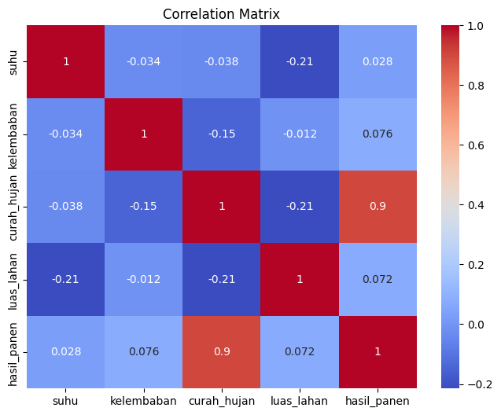

```python
import seaborn as sns
import matplotlib.pyplot as plt

plt.figure(figsize=(8,6))
sns.heatmap(df.corr(numeric_only=True), annot=True, cmap='coolwarm')
plt.title("Correlation Matrix")
plt.show()
```

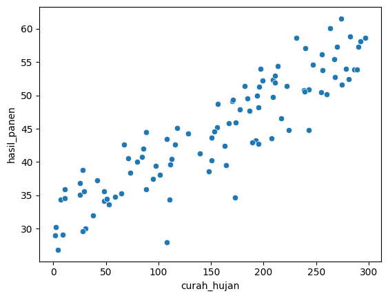

```python
sns.scatterplot(x='curah_hujan', y='hasil_panen', data=df)
plt.show()
```

### Insight Data

1. Curah hujan memiliki korelasi positif yang sangat kuat terhadap hasil panen (r ≈ 0.90). Hal ini menunjukkan bahwa curah hujan merupakan faktor utama yang mempengaruhi peningkatan hasil panen.
2. Luas lahan tidak memiliki hubungan yang signifikan terhadap hasil panen (r ≈ 0.07). Hal ini terlihat dari nilai korelasi yang sangat rendah serta distribusi luas lahan yang relatif seragam pada setiap kategori hasil panen.
3. Suhu dan kelembaban juga tidak menunjukkan pengaruh yang signifikan terhadap hasil panen (r ≈ 0.03 dan r ≈ 0.08). Dengan demikian, variabel-variabel tersebut memiliki kontribusi yang relatif kecil dibandingkan curah hujan.

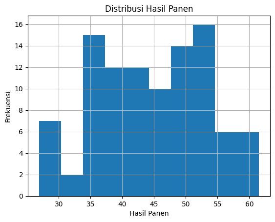

```python
# Histogram digunakan untuk melihat distribusi data hasil panen, sehingga dapat diketahui apakah data tersebar merata atau terdapat kecenderungan tertentu.
import matplotlib.pyplot as plt

df['hasil_panen'].hist()
plt.title("Distribusi Hasil Panen")
plt.xlabel("Hasil Panen")
plt.ylabel("Frekuensi")
plt.show()
```

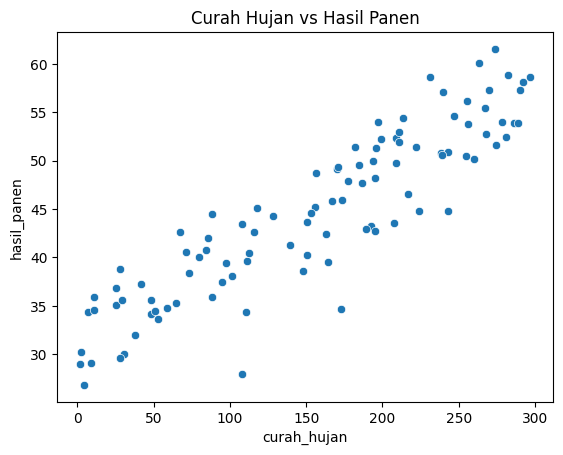

```python
#Scatter plot digunakan untuk melihat hubungan antara curah hujan dan hasil panen. Visualisasi ini membantu mengidentifikasi pola hubungan antar variabel.
import seaborn as sns

sns.scatterplot(x='curah_hujan', y='hasil_panen', data=df)
plt.title("Curah Hujan vs Hasil Panen")
plt.show()
```

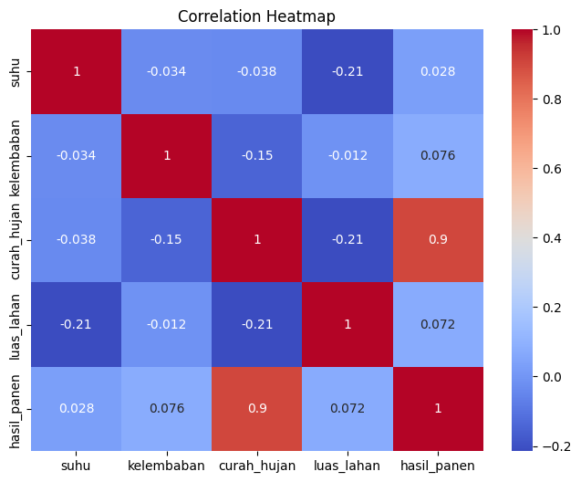

```python
#Heatmap digunakan untuk menampilkan korelasi antar variabel numerik secara visual, sehingga memudahkan dalam mengidentifikasi hubungan yang kuat maupun lemah.
plt.figure(figsize=(8,6))
sns.heatmap(df.corr(numeric_only=True), annot=True, cmap='coolwarm')
plt.title("Correlation Heatmap")
plt.show()
```

### Alasan Pemilihan Visualisasi

Histogram digunakan untuk memahami distribusi data. Scatter plot digunakan untuk melihat hubungan antar variabel, khususnya antara curah hujan dan hasil panen. Heatmap digunakan untuk menganalisis korelasi antar seluruh variabel numerik secara menyeluruh.

### Interpretasi Hasil

Distribusi hasil panen pada histogram menunjukkan bahwa data tersebar secara cukup merata tanpa adanya outlier yang ekstrem. Distribusi hasil panen tidak mengikuti pola normal, melainkan menunjukkan kecenderungan memiliki lebih dari satu puncak, khususnya pada rentang nilai sekitar 35–40 dan 50–55. Pola ini kemungkinan berkaitan dengan adanya kategori hasil panen (rendah, sedang, dan tinggi), di mana data cenderung terkumpul pada beberapa kelompok tertentu.

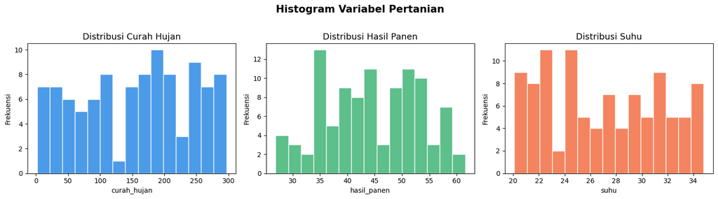

```python
import pandas as pd
import matplotlib.pyplot as plt

df = pd.read_csv('data_pertanian.csv')

fig, axes = plt.subplots(1, 3, figsize=(15, 4))

variables = ['curah_hujan', 'hasil_panen', 'suhu']
titles = ['Distribusi Curah Hujan', 'Distribusi Hasil Panen', 'Distribusi Suhu']
colors = ['#4C9BE8', '#5DBF8A', '#F4845F']

for i, (var, title, color) in enumerate(zip(variables, titles, colors)):
    axes[i].hist(df[var], bins=15, color=color, edgecolor='white')
    axes[i].set_title(title, fontsize=13)
    axes[i].set_xlabel(var)
    axes[i].set_ylabel('Frekuensi')

plt.suptitle('Histogram Variabel Pertanian', fontsize=15, fontweight='bold', y=1.02)
plt.tight_layout()
plt.savefig('histogram.png', dpi=150, bbox_inches='tight')
plt.show()
```

```python
# permasalahan dan analisis tambahan
```

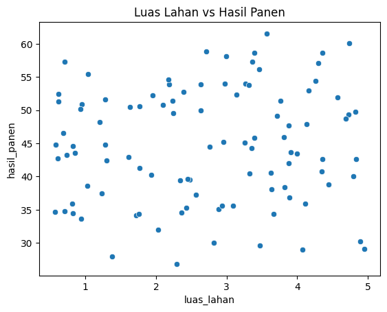

```python
#Kenapa luas lahan tidak berpengaruh?
sns.scatterplot(x='luas_lahan', y='hasil_panen', data=df)
plt.title("Luas Lahan vs Hasil Panen")
plt.show()
```

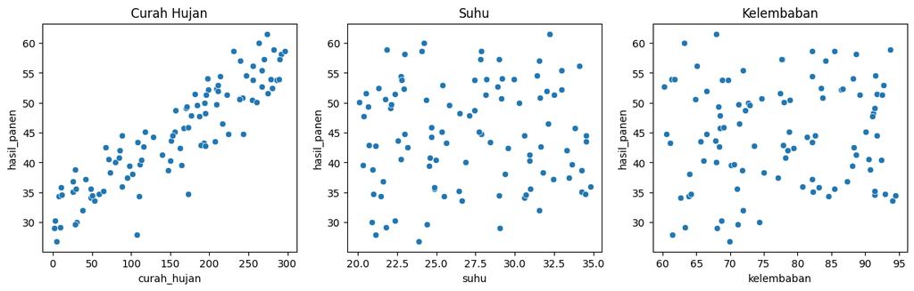

```python
# Seberapa kuat dominasi curah hujan?
fig, axes = plt.subplots(1, 3, figsize=(15,4))

sns.scatterplot(x='curah_hujan', y='hasil_panen', data=df, ax=axes[0])
axes[0].set_title("Curah Hujan")

sns.scatterplot(x='suhu', y='hasil_panen', data=df, ax=axes[1])
axes[1].set_title("Suhu")

sns.scatterplot(x='kelembaban', y='hasil_panen', data=df, ax=axes[2])
axes[2].set_title("Kelembaban")

plt.show()
```

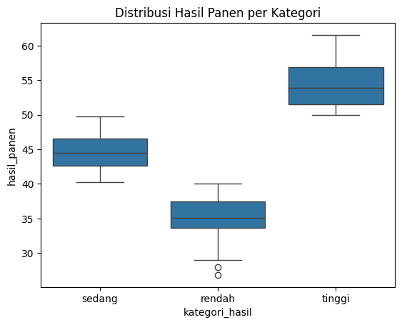

```python
# Apakah kategori_hasil benar-benar terpisah?
sns.boxplot(x='kategori_hasil', y='hasil_panen', data=df)
plt.title("Distribusi Hasil Panen per Kategori")
plt.show()
```

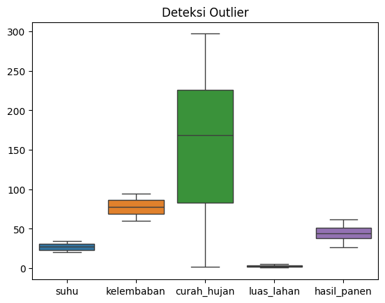

```python
# Apakah ada outlier?
sns.boxplot(data=df[['suhu','kelembaban','curah_hujan','luas_lahan','hasil_panen']])
plt.title("Deteksi Outlier")
plt.show()
```

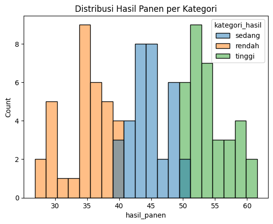

```python
# Apakah distribusi tiap kategori beda?
sns.histplot(data=df, x='hasil_panen', hue='kategori_hasil', bins=20)
plt.title("Distribusi Hasil Panen per Kategori")
plt.show()
```

```python
# Visualisasi tambahan menggunakan Tableau
```

[output not shown]